# Final Assignment

## Superhost Analysis

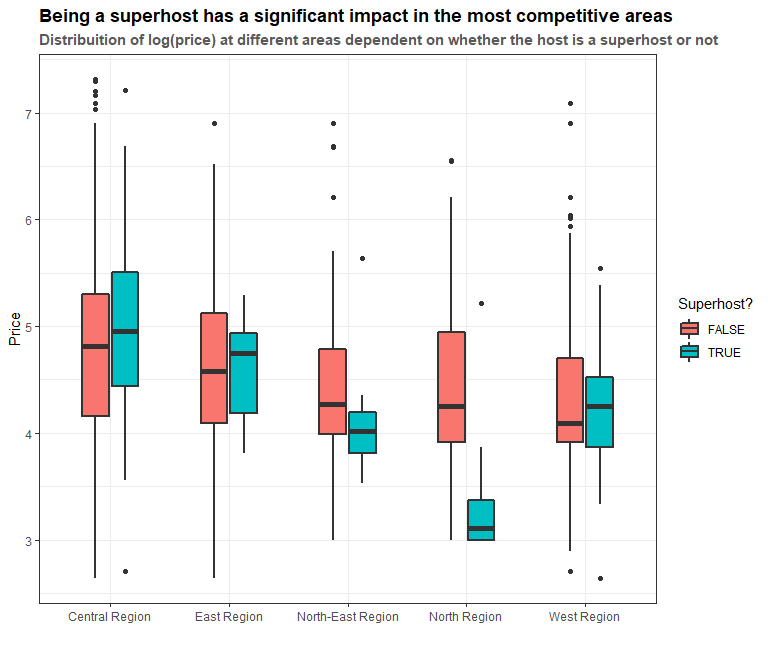

```r
# Superhost analysis

superhost_df <- filtered_listings %>%
  select(price, cleaning_fee, neighbourhood_group_cleansed, host_is_superhost, prop_type_simplified) %>%
  mutate(price_log = log(price)) %>%
  drop_na(host_is_superhost)

superhost_df %>%
  ggplot(aes(x = neighbourhood_group_cleansed, y = price_log, fill = host_is_superhost))+
  geom_boxplot(width=0.5,lwd=1) +
  theme_bw() +
  labs(title = "Being a superhost has a significant impact in the most competitive areas",
       subtitle = "Distribuition of log(price) at different areas dependent on whether the host is a superhost or not",
       x = "",
       y = "Price"
       )+
  scale_fill_discrete(name = "Superhost?") +
  theme(plot.title = element_text(face = "bold")) +
  theme(plot.subtitle = element_text(face = "bold", color = "grey35")) +
  theme(plot.caption = element_text(color = "grey68")) +
  NULL
```

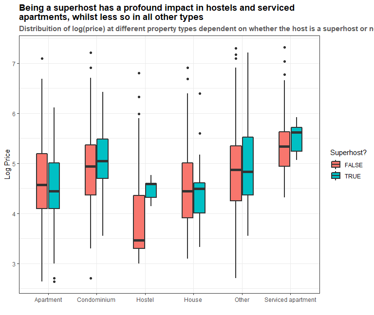

```r
superhost_df %>%
  ggplot(aes(x = prop_type_simplified, y = price_log, fill = host_is_superhost))+
  geom_boxplot(width=0.5,lwd=1) +
  theme_bw() +
  labs(title = "Being a superhost has a profound impact in hostels and serviced\napartments, whilst less so in all other types",
       subtitle = "Distribuition of log(price) at different property types dependent on whether the host is a superhost or not",
       x = "",
       y = "Log Price"
       )+
  scale_fill_discrete(name = "Superhost?") +
  theme(plot.title = element_text(face = "bold")) +
  theme(plot.subtitle = element_text(face = "bold", color = "grey35")) +
  theme(plot.caption = element_text(color = "grey68")) +
  NULL
```

## Demand Analysis of Airbnb in Singapore

The next piece of analysis we will perform is a demand for Airbnb in Singapore. We will have a look on the demand for Airbnb in Singapore over the years as well as at the seasonality of demand.

### Popularity of Airbnb in Singapore

We can clearly see some interesting patterns from the graph below:

From 2010 to around 2018, Airbnb demand indicated by reviews increases faster and faster and staged a little bit in the first half of 2018 and continued increased fast until mid 2019. There are two reasons behind the drop of demand from mid 2019: a) Singapore government announced in May 2019 that short-term rentals by platforms such as Airbnb remain illegal in Singapore b) COVID-19 came in 2020 which discourages travelers

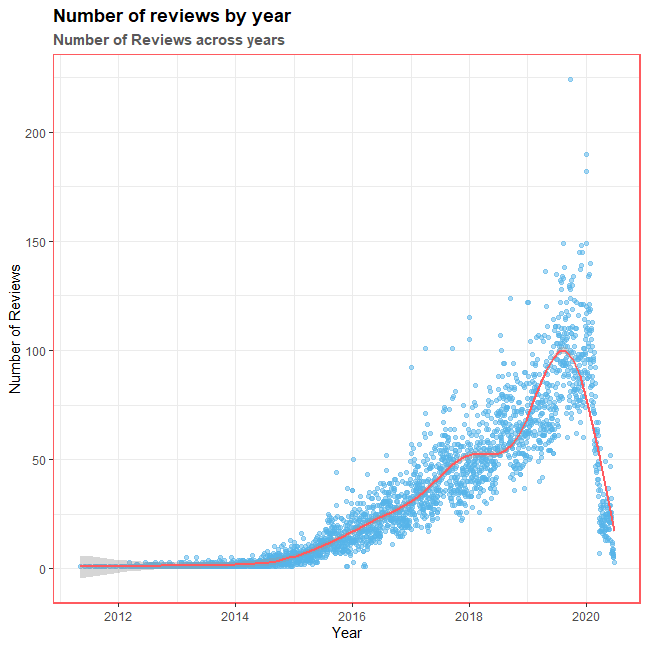

```r
#How popular is Airbnb in Singapore?

reviewsNum <- reviews %>%
  group_by(date = reviews$date) %>%
  summarise(number = n())

ggplot(reviewsNum, aes(date, number)) +
  geom_point(na.rm=TRUE, color = "#56B4E9", alpha=0.5) +
  geom_smooth(color = "#FF5A5F")+
  ggtitle("How popular is Airbnb in Singapore?",
          subtitle = "Number of Reviews across years") +
  labs(x = "Year", y = "Number of Reviews", title="Number of reviews by year") +
  theme_bw()+
  theme(plot.title = element_text(face = "bold")) +
  theme(plot.subtitle = element_text(face = "bold", color = "grey35")) +
  theme(plot.caption = element_text(color = "grey68"))+
  theme(panel.border = element_rect(colour = "#FF5A5F", fill=NA, size=1))
```

### Seasonality of Airbnb Demand in Singapore

We chose 2017,2018,2019 to see the seasonality of demand since Airbnb gains stable growth in these years and 2017,2018 and 2019 give different overall demand trends.

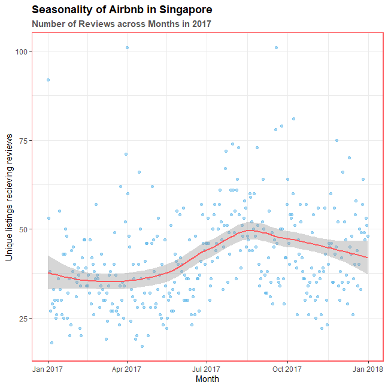

```r
#demand 2017
ggplot(reviewsNum[year(reviewsNum$date) == 2017,], aes(date, number)) +
  geom_point(na.rm=TRUE, color = "#56B4E9", alpha=0.5) +
  geom_smooth(color = "#FF5A5F")+
  ggtitle("Seasonality of Airbnb in Singapore",
          subtitle = "Number of Reviews across Months in 2017") +
  labs(x = "Month", y = "Unique listings recieving reviews") +
  theme_bw()+
  theme(plot.title = element_text(face = "bold")) +
  theme(plot.subtitle = element_text(face = "bold", color = "grey35")) +
  theme(plot.caption = element_text(color = "grey68"))+
  theme(panel.border = element_rect(colour = "#FF5A5F", fill=NA, size=1))
```

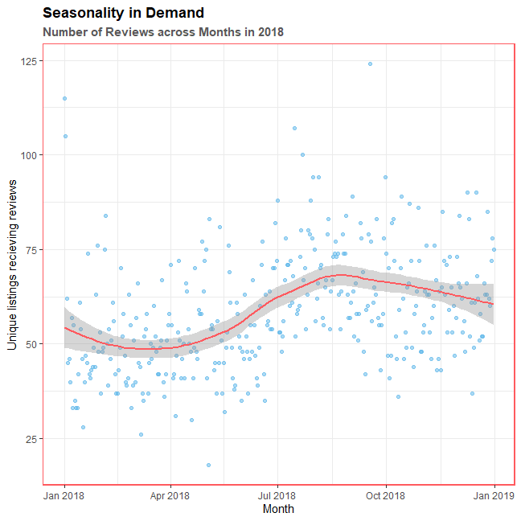

```r
#demand 2018
ggplot(reviewsNum[year(reviewsNum$date) == 2018,], aes(date, number)) +
  geom_point(na.rm=TRUE, color = "#56B4E9", alpha=0.5) +
  geom_smooth(color = "#FF5A5F")+
  ggtitle("Seasonality in Demand",
          subtitle = "Number of Reviews across Months in 2018") +
  labs(x = "Month", y = "Unique listings recieving reviews") +
  theme_bw()+
  theme(plot.title = element_text(face = "bold")) +
  theme(plot.subtitle = element_text(face = "bold", color = "grey35")) +
  theme(plot.caption = element_text(color = "grey68"))+
  theme(panel.border = element_rect(colour = "#FF5A5F", fill=NA, size=1))
```

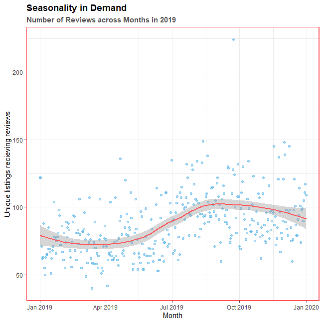

```r
#demand 2019
demand2019 <- ggplot(reviewsNum[year(reviewsNum$date) == 2019,], aes(date, number)) +
  geom_point(na.rm=TRUE, color = "#56B4E9", alpha=0.5) +
  geom_smooth(color = "#FF5A5F")+
  ggtitle("Seasonality in Demand",
          subtitle = "Number of Reviews across Months in 2019") +
  labs(x = "Month", y = "Unique listings recieving reviews") +
  theme_bw()+
  theme(plot.title = element_text(face = "bold")) +
  theme(plot.subtitle = element_text(face = "bold", color = "grey35")) +
  theme(plot.caption = element_text(color = "grey68"))+
  theme(panel.border = element_rect(colour = "#FF5A5F", fill=NA, size=1))

demand2019
```

No matter the overall demand trend is roaring(in 2017), staging(in 2018) or fluctuating(in 2019), the charts above show strong seasonality of Airbnb demand in Singapore: bottom in Apr and top in Sep.

The final part of analysis prior to building up our models, is a heatmap of Average Daily Prices from 2019 to 2020.

```r
# # Download calendar data about AirBnB bookings in Singapore from March 2019 to July 2020 (including later dates)
# # Selecting the needed values to reduce amount of data

 a <- calendar_june_2020 <- vroom("http://data.insideairbnb.com/singapore/sg/singapore/2020-06-22/data/calendar.csv.gz") %>% # June 2020
   select(price, date, listing_id)

 b <- calendar_may_2020 <- vroom("http://data.insideairbnb.com/singapore/sg/singapore/2020-05-27/data/calendar.csv.gz") %>% # May 2020
   select(price, date, listing_id)

 c <- calendar_april_2020 <- vroom("http://data.insideairbnb.com/singapore/sg/singapore/2020-04-26/data/calendar.csv.gz") %>% # April 2020
   select(price, date, listing_id)

 d <- calendar_march_2020 <- vroom("http://data.insideairbnb.com/singapore/sg/singapore/2020-03-21/data/calendar.csv.gz") %>% # March 2020
   select(price, date, listing_id)

 e <- calendar_february_2020 <- vroom("http://data.insideairbnb.com/singapore/sg/singapore/2020-02-27/data/calendar.csv.gz") %>% # February 2020
   select(price, date, listing_id)

 f <- calendar_january_2020 <- vroom("http://data.insideairbnb.com/singapore/sg/singapore/2020-01-26/data/calendar.csv.gz") %>% # January 2020
   select(price, date, listing_id)

 g <- calendar_december_2019 <- vroom("http://data.insideairbnb.com/singapore/sg/singapore/2019-12-28/data/calendar.csv.gz") %>% # December 2019
   select(price, date, listing_id)

 h <- calendar_november_2019 <- vroom("http://data.insideairbnb.com/singapore/sg/singapore/2019-11-26/data/calendar.csv.gz") %>% # November 2019
   select(price, date, listing_id)

 i <- calendar_october_2019 <- vroom("http://data.insideairbnb.com/singapore/sg/singapore/2019-10-25/data/calendar.csv.gz") %>% # October 2019
   select(price, date, listing_id)

 j <- calendar_september_2019 <- vroom("http://data.insideairbnb.com/singapore/sg/singapore/2019-09-25/data/calendar.csv.gz") %>% # September 2019
   select(price, date, listing_id)

 k <- calendar_august_2019 <- vroom("http://data.insideairbnb.com/singapore/sg/singapore/2019-08-28/data/calendar.csv.gz") %>% # August 2019
   select(price, date, listing_id)

 l <- calendar_july_2019 <- vroom("http://data.insideairbnb.com/singapore/sg/singapore/2019-07-21/data/calendar.csv.gz") %>% # July 2019
   select(price, date, listing_id)

 m <- calendar_june_2019 <- vroom("http://data.insideairbnb.com/singapore/sg/singapore/2019-06-25/data/calendar.csv.gz") %>% # June 2019
   select(price, date, listing_id)

 n <- calendar_may_2019 <- vroom("http://data.insideairbnb.com/singapore/sg/singapore/2019-05-23/data/calendar.csv.gz") %>% # May 2019
   select(price, date, listing_id)

 o <- calendar_april_2019 <- vroom("http://data.insideairbnb.com/singapore/sg/singapore/2019-04-20/data/calendar.csv.gz") %>% # April 2019
   select(price, date, listing_id)

 p <- calendar_march_2019 <- vroom("http://data.insideairbnb.com/singapore/sg/singapore/2019-03-18/data/calendar.csv.gz") %>% # March 2019
   select(price, date, listing_id)


# # Merging Data from all months and deleting

 calendar_add_up <- bind_rows(a,b,c,d,e,f,g,h,i,j,k,l,m,n,o,p) %>% # Combine the data sets for all 16 months

   filter(date < "2020-06-01" & date > "2019-05-31") %>% # Filter out one year of data to include as much "overlapping" data as possible

   mutate(price = parse_number(price)) # Remove dollar writing
```

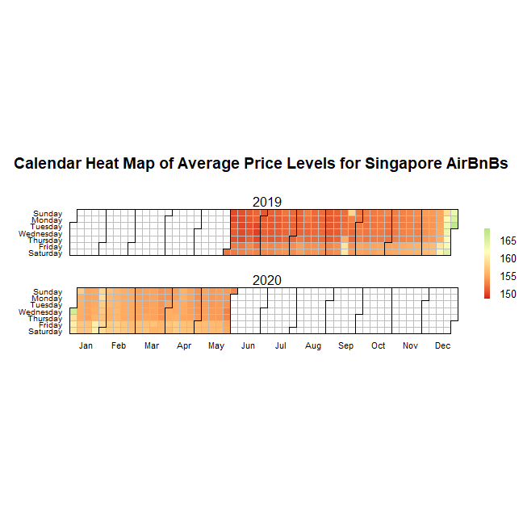

```r
# # Color Setting

 r2g <- c("#D61818", "#FFAE63", "#FFFFBD", "#B5E384")

# # Create

 groupedCalendar <- # Since we need the value for every single day, we need to group it

   calendar_add_up %>% # Taking the cleaned data from above

   filter(price < 1500) %>% # Setting an upper price limit to avoid a distorted mean

   group_by(date) %>% # put the data for every single day together

   summarise(totalPrice = sum(price, na.rm = TRUE), # Due to problems of the heatmap handling "mean" we need to do it the old-fashioned way

             totalListings = n()) %>% # Devide the sum by the count

   mutate(mean = totalPrice/totalListings) # This comes into a new column of daily average prices

 calendarHeat(groupedCalendar$date, # Building the graphic by date

              groupedCalendar$mean, # Taking the mean or average daily price as variable

              ncolors = 99, # Giving a color range from green to red in 99 shades (unsure if fully used)

              color = "r2g", # Giving a color selection (Red to Green)

              varname="Average Price Levels for Singapore AirBnBs") # Naming the variable accordingly to get the right header
```

# Regression Analysis

We looked at the distribution of price during our exploratory data analysis. We found that price lacked normality so we used log10 to normalize it. Moving forward, we will use log_4_nights as our target variable.

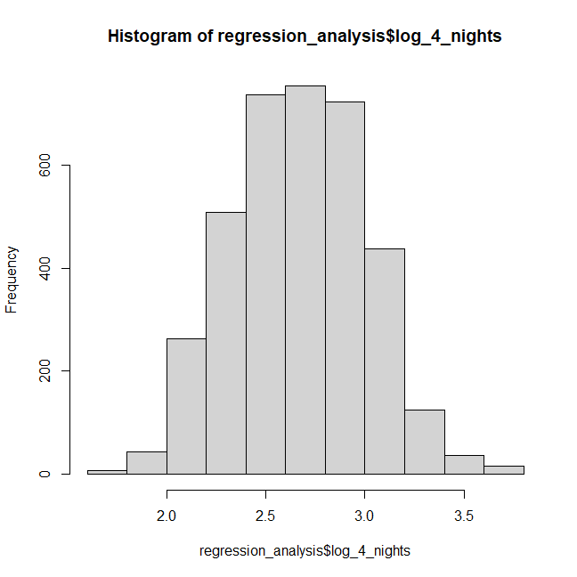

```r
##create column for price of 4 nights
regression_analysis <- filtered_listings %>%
  mutate(price_4_nights =
           price*4 +
           cleaning_fee +
           extra_people,
         log_4_nights = log10(price_4_nights)
         )

#check histogram of new variable to check for normality
hist(regression_analysis$log_4_nights)
```

```r
## log of 4 nights give a much more normal data set so we will use this moving forward

# summary stats on 4 nights by property type
favstats(~log_4_nights | prop_type_simplified, data = regression_analysis)
```

| prop_type_simplified | min | Q1 | median | Q3 | max | mean | sd | n | missing |
| --- | --- | --- | --- | --- | --- | --- | --- | --- | --- |
| Apartment | 1.75 | 2.42 | 2.62 | 2.86 | 3.68 | 2.64 | 0.307 | 1419 | 0 |
| Condominium | 1.78 | 2.54 | 2.8 | 2.96 | 3.73 | 2.76 | 0.276 | 793 | 0 |
| Hostel | 1.94 | 2.1 | 2.18 | 2.54 | 3.56 | 2.34 | 0.329 | 306 | 0 |
| House | 2.02 | 2.38 | 2.59 | 2.76 | 3.6 | 2.58 | 0.317 | 306 | 0 |
| Other | 1.78 | 2.48 | 2.74 | 2.94 | 3.77 | 2.73 | 0.334 | 639 | 0 |
| Serviced apartment | 2.56 | 2.8 | 2.96 | 3.08 | 3.78 | 2.97 | 0.217 | 185 | 0 |

We then created model1 using prop_type_simplified, number_of_reviews, and review_scores_rating.The review_scores_rating coefficient is .001, so for every review score increase, it increases the price by around 1. The prop_type_simplified coefficients are .095, -.312, -.107, .041, .28 for condominiums, hostels, houses, other, and serviced apartments, respectively. This translates to affecting the price by 1.24, -.49, .78, 1.10, and 1.91 depending on property type.

We also constructed model2, which is model1 plus room_type. The addition of room_type to our model increased our R2 from .171 to .473 and each room_type variable was significantly significant at p < .001. It is fair to say that room_type is a significant predictor of cost.

Our first 4 models are shown below:

```r
##makes first 2 models using instructions from Kostis
model1 <- lm(log_4_nights ~
               prop_type_simplified +
               number_of_reviews +
               review_scores_rating,
             data = regression_analysis)

model2 <- lm(log_4_nights ~
               prop_type_simplified +
               number_of_reviews +
               review_scores_rating  +
               room_type,
             data = regression_analysis)

#model 3 adds superhost
model3 <- lm(log_4_nights ~
               prop_type_simplified +
               number_of_reviews +
               review_scores_rating  +
               room_type +
               host_is_superhost,
             data = regression_analysis)

##model 4 adds neigihbourhood group (cleansed)
model4 <- lm(log_4_nights ~
               prop_type_simplified +
               number_of_reviews +
               review_scores_rating  +
               room_type +
               host_is_superhost +
               neighbourhood_group_cleansed,
             data = regression_analysis)
huxreg(model1, model2, model3, model4)
```

|  | (1) | (2) | (3) | (4) |
| --- | --- | --- | --- | --- |
| (Intercept) | 2.540 *** | 2.765 *** | 2.783 *** | 2.785 *** |
|  | (0.043) | (0.035) | (0.036) | (0.035) |
| prop_type_simplifiedCondominium | 0.095 *** | 0.025 | 0.022 | 0.021 |
|  | (0.016) | (0.013) | (0.013) | (0.013) |
| prop_type_simplifiedHostel | -0.312 *** | -0.084 *** | -0.083 *** | -0.100 *** |
|  | (0.021) | (0.023) | (0.023) | (0.023) |
| prop_type_simplifiedHouse | -0.107 *** | -0.008 | -0.012 | -0.009 |
|  | (0.022) | (0.018) | (0.018) | (0.018) |
| prop_type_simplifiedOther | 0.041 * | 0.171 *** | 0.167 *** | 0.155 *** |
|  | (0.017) | (0.014) | (0.014) | (0.014) |
| prop_type_simplifiedServiced apartment | 0.280 *** | 0.282 *** | 0.277 *** | 0.267 *** |
|  | (0.029) | (0.025) | (0.025) | (0.025) |
| number_of_reviews | -0.000 ** | -0.001 *** | -0.001 *** | -0.001 *** |
|  | (0.000) | (0.000) | (0.000) | (0.000) |
| review_scores_rating | 0.001 ** | 0.001 *** | 0.001 ** | 0.001 ** |
|  | (0.000) | (0.000) | (0.000) | (0.000) |
| room_typeHotel room |  | -0.378 *** | -0.380 *** | -0.373 *** |
|  |  | (0.022) | (0.022) | (0.022) |
| room_typePrivate room |  | -0.369 *** | -0.371 *** | -0.355 *** |
|  |  | (0.011) | (0.011) | (0.011) |
| room_typeShared room |  | -0.623 *** | -0.627 *** | -0.611 *** |
|  |  | (0.025) | (0.025) | (0.025) |
| host_is_superhostTRUE |  |  | 0.028 * | 0.031 * |
|  |  |  | (0.014) | (0.014) |
| neighbourhood_group_cleansedEast Region |  |  |  | -0.014 |
|  |  |  |  | (0.019) |
| neighbourhood_group_cleansedNorth-East Region |  |  |  | -0.083 *** |
|  |  |  |  | (0.025) |
| neighbourhood_group_cleansedNorth Region |  |  |  | -0.122 *** |
|  |  |  |  | (0.033) |
| neighbourhood_group_cleansedWest Region |  |  |  | -0.083 *** |
|  |  |  |  | (0.019) |
| N | 2433 | 2433 | 2419 | 2419 |
| R2 | 0.171 | 0.473 | 0.475 | 0.483 |
| logLik | -414.940 | 136.523 | 134.989 | 154.063 |
| AIC | 847.880 | -249.046 | -243.978 | -274.126 |
| *** p < 0.001; ** p < 0.01; * p < 0.05. |  |  |  |  |

In model5, we wanted to add both the accommodates variable and the number of bedrooms variable, checking the VIF to make sure the two are not creating collinearitiy issues.

In model7, we added security deposit, which increased our R2 slightly.

In model8, we can see that the is_location_exact indicator did not have a statistically significant effect, so moving forward we left it out of our model. We can conclude that having the exact location is not a significant indicator of price.

In model 9, we looked at the effect of cancellation policy after controlling for other variables. We found that this variable was only significant for properties that had a super strict 60 day policy, which was only on 4 properties, so we decided to exclude this from our final model.

```r
##model 5 adds accommodates and bedroom count
model5 <- lm(log_4_nights ~
               prop_type_simplified +
               number_of_reviews +
               review_scores_rating  +
               room_type +
               host_is_superhost +
               accommodates +
               bedrooms,
             data = regression_analysis)

##added latiitude
model6 <- lm(log_4_nights ~
               prop_type_simplified +
               number_of_reviews +
               review_scores_rating  +
               room_type +
               host_is_superhost +
               accommodates +
               bedrooms +
               latitude,
             data = regression_analysis)

##add security deposit
model7 <- lm(log_4_nights ~
               prop_type_simplified +
               number_of_reviews +
               review_scores_rating  +
               room_type +
               host_is_superhost +
               accommodates +
               bedrooms +
               latitude +
               security_deposit,
             data = regression_analysis)

# added is_location_exact
model8 <-  lm(log_4_nights ~
               prop_type_simplified +
               number_of_reviews +
               review_scores_rating  +
               room_type +
               host_is_superhost +
               accommodates +
               bedrooms +
               latitude +
               security_deposit +
                is_location_exact,
             data = regression_analysis)

#added cancellation policy
model9 <-  lm(log_4_nights ~
               prop_type_simplified +
               number_of_reviews +
               review_scores_rating  +
               room_type +
               host_is_superhost +
               accommodates +
               bedrooms +
               latitude +
               security_deposit +
                is_location_exact +
                cancellation_policy,
             data = regression_analysis)

##summarize these models
huxreg(model5, model6, model7, model8, model9)
```

|  | (1) | (2) | (3) | (4) | (5) |
| --- | --- | --- | --- | --- | --- |
| (Intercept) | 2.469 *** | 4.662 *** | 4.663 *** | 4.605 *** | 4.590 *** |
|  | (0.035) | (0.200) | (0.199) | (0.202) | (0.202) |
| prop_type_simplifiedCondominium | 0.019 | 0.017 | 0.017 | 0.016 | 0.017 |
|  | (0.012) | (0.011) | (0.011) | (0.011) | (0.011) |
| prop_type_simplifiedHostel | -0.134 *** | -0.166 *** | -0.161 *** | -0.161 *** | -0.156 *** |
|  | (0.022) | (0.022) | (0.021) | (0.021) | (0.022) |
| prop_type_simplifiedHouse | -0.021 | -0.013 | -0.016 | -0.018 | -0.017 |
|  | (0.016) | (0.016) | (0.016) | (0.016) | (0.016) |
| prop_type_simplifiedOther | 0.169 *** | 0.146 *** | 0.147 *** | 0.146 *** | 0.146 *** |
|  | (0.013) | (0.013) | (0.013) | (0.013) | (0.013) |
| prop_type_simplifiedServiced apartment | 0.274 *** | 0.255 *** | 0.252 *** | 0.251 *** | 0.241 *** |
|  | (0.022) | (0.022) | (0.022) | (0.022) | (0.022) |
| number_of_reviews | -0.001 *** | -0.001 *** | -0.001 *** | -0.001 *** | -0.001 *** |
|  | (0.000) | (0.000) | (0.000) | (0.000) | (0.000) |
| review_scores_rating | 0.002 *** | 0.002 *** | 0.002 *** | 0.002 *** | 0.002 *** |
|  | (0.000) | (0.000) | (0.000) | (0.000) | (0.000) |
| room_typeHotel room | -0.291 *** | -0.287 *** | -0.275 *** | -0.274 *** | -0.271 *** |
|  | (0.020) | (0.020) | (0.020) | (0.020) | (0.020) |
| room_typePrivate room | -0.274 *** | -0.247 *** | -0.234 *** | -0.234 *** | -0.232 *** |
|  | (0.011) | (0.011) | (0.011) | (0.011) | (0.011) |
| room_typeShared room | -0.534 *** | -0.505 *** | -0.491 *** | -0.490 *** | -0.488 *** |
|  | (0.023) | (0.023) | (0.023) | (0.023) | (0.023) |
| host_is_superhostTRUE | 0.051 *** | 0.050 *** | 0.048 *** | 0.048 *** | 0.048 *** |
|  | (0.012) | (0.012) | (0.012) | (0.012) | (0.012) |
| accommodates | 0.019 *** | 0.019 *** | 0.019 *** | 0.019 *** | 0.019 *** |
|  | (0.002) | (0.002) | (0.002) | (0.002) | (0.002) |
| bedrooms | 0.080 *** | 0.081 *** | 0.079 *** | 0.079 *** | 0.080 *** |
|  | (0.006) | (0.006) | (0.006) | (0.006) | (0.006) |
| latitude |  | -1.677 *** | -1.682 *** | -1.649 *** | -1.641 *** |
|  |  | (0.151) | (0.150) | (0.151) | (0.151) |
| security_deposit |  |  | 0.000 *** | 0.000 *** | 0.000 *** |
|  |  |  | (0.000) | (0.000) | (0.000) |
| is_location_exactTRUE |  |  |  | 0.018 | 0.017 |
|  |  |  |  | (0.010) | (0.010) |
| cancellation_policymoderate |  |  |  |  | -0.019 |
|  |  |  |  |  | (0.014) |
| cancellation_policystrict_14_with_grace_period |  |  |  |  | 0.006 |
|  |  |  |  |  | (0.012) |
| cancellation_policysuper_strict_30 |  |  |  |  | 0.383 |
|  |  |  |  |  | (0.202) |
| cancellation_policysuper_strict_60 |  |  |  |  | 0.487 * |
|  |  |  |  |  | (0.202) |
| N | 2415 | 2415 | 2415 | 2415 | 2415 |
| R2 | 0.571 | 0.592 | 0.597 | 0.598 | 0.600 |
| logLik | 377.765 | 438.219 | 453.583 | 455.147 | 462.623 |
| AIC | -725.530 | -844.439 | -873.167 | -874.294 | -881.246 |
| *** p < 0.001; ** p < 0.01; * p < 0.05. |  |  |  |  |  |

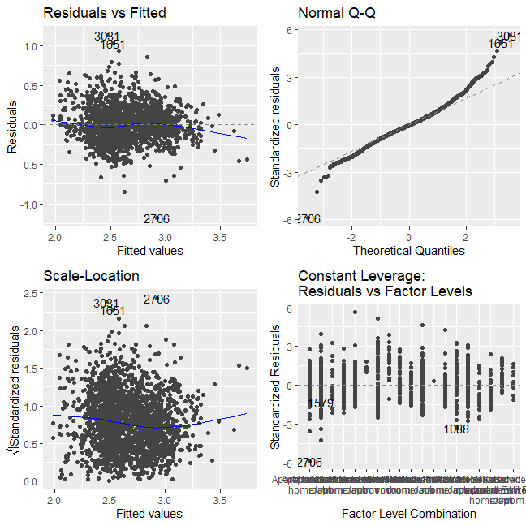

```r
#residuals check
autoplot(model7)
```

```r
##check for collinearity
car::vif(model7)
```

```
##                      GVIF Df GVIF^(1/(2*Df))
## prop_type_simplified 2.90  5            1.11
## number_of_reviews    1.04  1            1.02
## review_scores_rating 1.11  1            1.05
## room_type            3.23  3            1.22
## host_is_superhost    1.10  1            1.05
## accommodates         1.68  1            1.30
## bedrooms             1.57  1            1.25
## latitude             1.16  1            1.08
## security_deposit     1.12  1            1.06
```

```r
##renaming the final model
final_model <- model7

## summarize final model
msummary(final_model)
```

```
##                                         Estimate Std. Error t value Pr(>|t|)
## (Intercept)                             4.66e+00   1.99e-01   23.41  < 2e-16
## prop_type_simplifiedCondominium         1.66e-02   1.13e-02    1.47     0.14
## prop_type_simplifiedHostel             -1.61e-01   2.15e-02   -7.50  9.2e-14
## prop_type_simplifiedHouse              -1.57e-02   1.58e-02   -0.99     0.32
## prop_type_simplifiedOther               1.47e-01   1.28e-02   11.45  < 2e-16
## prop_type_simplifiedServiced apartment  2.52e-01   2.19e-02   11.51  < 2e-16
## number_of_reviews                      -6.72e-04   9.65e-05   -6.97  4.2e-12
## review_scores_rating                    1.91e-03   3.45e-04    5.53  3.5e-08
## room_typeHotel room                    -2.75e-01   1.96e-02  -14.06  < 2e-16
## room_typePrivate room                  -2.34e-01   1.10e-02  -21.31  < 2e-16
## room_typeShared room                   -4.91e-01   2.25e-02  -21.78  < 2e-16
## host_is_superhostTRUE                   4.84e-02   1.21e-02    4.01  6.3e-05
## accommodates                            1.89e-02   1.79e-03   10.56  < 2e-16
## bedrooms                                7.93e-02   5.95e-03   13.32  < 2e-16
## latitude                               -1.68e+00   1.50e-01  -11.20  < 2e-16
## security_deposit                        1.07e-04   1.92e-05    5.54  3.3e-08
##
## (Intercept)                            ***
## prop_type_simplifiedCondominium
## prop_type_simplifiedHostel             ***
## prop_type_simplifiedHouse
## prop_type_simplifiedOther              ***
## prop_type_simplifiedServiced apartment ***
## number_of_reviews                      ***
## review_scores_rating                   ***
## room_typeHotel room                    ***
## room_typePrivate room                  ***
## room_typeShared room                   ***
## host_is_superhostTRUE                  ***
## accommodates                           ***
## bedrooms                               ***
## latitude                               ***
## security_deposit                       ***
##
## Residual standard error: 0.201 on 2399 degrees of freedom
##   (1233 observations deleted due to missingness)
## Multiple R-squared:  0.597,  Adjusted R-squared:  0.595
## F-statistic:  237 on 15 and 2399 DF,  p-value: <2e-16
```

```r
confint(final_model)
```

```
##                                            2.5 %    97.5 %
## (Intercept)                             4.27e+00  5.053654
## prop_type_simplifiedCondominium        -5.59e-03  0.038715
## prop_type_simplifiedHostel             -2.03e-01 -0.118833
## prop_type_simplifiedHouse              -4.66e-02  0.015235
## prop_type_simplifiedOther               1.22e-01  0.171857
## prop_type_simplifiedServiced apartment  2.09e-01  0.294588
## number_of_reviews                      -8.61e-04 -0.000483
## review_scores_rating                    1.23e-03  0.002581
## room_typeHotel room                    -3.14e-01 -0.236914
## room_typePrivate room                  -2.56e-01 -0.212814
## room_typeShared room                   -5.35e-01 -0.446643
## host_is_superhostTRUE                   2.47e-02  0.072123
## accommodates                            1.54e-02  0.022413
## bedrooms                                6.77e-02  0.091018
## latitude                               -1.98e+00 -1.387339
## security_deposit                        6.89e-05  0.000144
```

We then used our final model to predict the cost of 1 person staying in a private room in a Singapore apartment for 4 nights. We set number of reviews to 10 and the score rating to 90. Further, we elected to have a superhost for our accommodation. We have set latitude and security deposit to the averages for our dataset. We have printed the fitted value and a 95% confidence interval below. After anti-logging our results, we predicted a 302USD price with a 95% confidence interval [282,324].

```r
## Using our model to predict price
predictors <- data.frame(prop_type_simplified = "Apartment",
                         number_of_reviews = 10,
                         review_scores_rating = 90,
                         room_type = "Private room",
                         host_is_superhost = TRUE,
                         accommodates = 1,
                         bedrooms = 1,
                         latitude = 1.35,
                         security_deposit = 93)

predict(final_model, newdata = predictors, interval="confidence")
```

```
##    fit  lwr  upr
## 1 2.48 2.45 2.51
```

# Results & Conclusion

Using our final model, we were able to predict a price of around $302. We are 95% confident that the cost of 4 nights (including cleaning fee and extra people) in a 1 bedroom private room in a Singapore apartment falls between 282 and 324 USD. To check our results for accuracy, we looked at the AirBnB website for similar listings and found that the average price per night for all properties was 115USD, which translates to around 460USD for 4 nights. Since we are only looking for private rooms that sleep 1, it makes sense that our prediction was a bit lower.

# Conclusion

The goal of our project was to be able to predict the priice of staying 4 nights in a Singapore AirBnB that met the following parameters: - private room - 1 bedroom - apartment - more than 10 reviews - average review rating above 90

During our Exploratory Data Analysis, we were able to identify the effects different variables had on price. Further, we were able to identify any multicollinearity before building our regression model. After building different models and identifying our final model, our R-squared approached the 60% level.

Using our final model, we predicted that 4 nights in Singapore with our specific parameters would cost around 302 USD. We had a 95% confidence interval between 282 and 324 USD.

In the future, we would need more complete data to provide the best possible model.